# Group8_Project

Misha Aggarwal, Madalina Dumitrescu, Yung-Chieh Hsu, Wendy Li, Christoph Plachutta, Tianyi Zhang

2022-09-16

```r
theme_set(theme_bw())
```

# 1 Exploratory Data Analysis

## 1.1 Inspecting and Cleaning the Data

As a first step to our EDA, we loud our data into the environment and assign it to variables. We use vroom, as it is superior in speed compared to read.csv.

```r
# Load data into environment and assign to variables
sales <- vroom::vroom("data/sales.csv")
details <- vroom::vroom("data/details.csv")
stores <- vroom::vroom("data/stores.csv")
```

Next, we apply janitor::clean_names to bring the column names in order, to also make it easier joinable in the future.

```r
# Clean names of data frames
sales <- janitor::clean_names(sales)
details <- janitor::clean_names(details)
stores <- janitor::clean_names(stores)
```

By inspecting the data, we can see problems that may affect our future analysis. For each data frame, we change types for some of the variables.

```r
# Inspect Sales data frame
skim(sales)
```

Data summary

| Name | sales |
| --- | --- |
| Number of rows | 421570 |
| Number of columns | 5 |
| _______________________ |  |
| Column type frequency: |  |
| character | 1 |
| logical | 1 |
| numeric | 3 |
| ________________________ |  |
| Group variables | None |

**Variable type: character**

| skim_variable | n_missing | complete_rate | min | max | empty | n_unique | whitespace |
| --- | --- | --- | --- | --- | --- | --- | --- |
| date | 0 | 1 | 10 | 10 | 0 | 143 | 0 |

**Variable type: logical**

| skim_variable | n_missing | complete_rate | mean | count |
| --- | --- | --- | --- | --- |
| is_holiday | 0 | 1 | 0.07 | FAL: 391909, TRU: 29661 |

**Variable type: numeric**

| skim_variable | n_missing | complete_rate | mean | sd | p0 | p25 | p50 | p75 | p100 | hist |
| --- | --- | --- | --- | --- | --- | --- | --- | --- | --- | --- |
| store | 0 | 1 | 22.2 | 12.8 | 1 | 11 | 22 | 33 | 45 | ▇▇▇▇▇ |
| dept | 0 | 1 | 44.3 | 30.5 | 1 | 18 | 37 | 74 | 99 | ▇▇▅▂▆ |
| weekly_sales | 0 | 1 | 16092.7 | 22873.1 | -4991 | 2095 | 7668 | 20337 | 671916 | ▇▁▁▁▁ |

```r
glimpse(sales)
```

```
## Rows: 421,570
## Columns: 5
## $ store        <dbl> 1, 1, 1, 1, 1, 1, 1, 1, 1, 1, 1, 1, 1, 1, 1, 1, 1, 1, 1, …
## $ dept         <dbl> 1, 1, 1, 1, 1, 1, 1, 1, 1, 1, 1, 1, 1, 1, 1, 1, 1, 1, 1, …
## $ date         <chr> "05/02/2010", "12/02/2010", "19/02/2010", "26/02/2010", "…
## $ is_holiday   <lgl> FALSE, TRUE, FALSE, FALSE, FALSE, FALSE, FALSE, FALSE, FA…
## $ weekly_sales <dbl> 25355, 45621, 43678, 19192, 21564, 21474, 22396, 26049, 5…
```

```r
head(sales)
```

| store | dept | date | is_holiday | weekly_sales |
| --- | --- | --- | --- | --- |
| 1 | 1 | 05/02/2010 | FALSE | 2.54e+04 |
| 1 | 1 | 12/02/2010 | TRUE | 4.56e+04 |
| 1 | 1 | 19/02/2010 | FALSE | 4.37e+04 |
| 1 | 1 | 26/02/2010 | FALSE | 1.92e+04 |
| 1 | 1 | 05/03/2010 | FALSE | 2.16e+04 |
| 1 | 1 | 12/03/2010 | FALSE | 2.15e+04 |

```r
# Change store ID and dept to factor
sales <- sales %>%
  mutate(store = as.factor(store),
         dept = as.factor(dept),
         # Change date format
         date = dmy(date))
```

```r
# Inspect Sales data frame
skim(details)
```

Data summary

| Name | details |
| --- | --- |
| Number of rows | 8190 |
| Number of columns | 12 |
| _______________________ |  |
| Column type frequency: |  |
| character | 1 |
| logical | 1 |
| numeric | 10 |
| ________________________ |  |
| Group variables | None |

**Variable type: character**

| skim_variable | n_missing | complete_rate | min | max | empty | n_unique | whitespace |
| --- | --- | --- | --- | --- | --- | --- | --- |
| date | 0 | 1 | 10 | 10 | 0 | 182 | 0 |

**Variable type: logical**

| skim_variable | n_missing | complete_rate | mean | count |
| --- | --- | --- | --- | --- |
| is_holiday | 0 | 1 | 0.07 | FAL: 7605, TRU: 585 |

**Variable type: numeric**

| skim_variable | n_missing | complete_rate | mean | sd | p0 | p25 | p50 | p75 | p100 | hist |
| --- | --- | --- | --- | --- | --- | --- | --- | --- | --- | --- |
| store | 0 | 1.00 | 23.00 | 12.99 | 1.00 | 12.00 | 23.00 | 34.00 | 4.50e+01 | ▇▇▇▇▇ |
| temperature | 0 | 1.00 | 59.36 | 18.68 | -7.29 | 45.90 | 60.71 | 73.88 | 1.02e+02 | ▁▂▆▇▃ |
| fuel_price | 0 | 1.00 | 3.41 | 0.43 | 2.47 | 3.04 | 3.51 | 3.74 | 4.47e+00 | ▅▅▇▇▁ |
| mark_down1 | 4158 | 0.49 | 7032.37 | 9262.75 | -2781.45 | 1577.53 | 4743.58 | 8923.31 | 1.03e+05 | ▇▁▁▁▁ |
| mark_down2 | 5269 | 0.36 | 3384.18 | 8793.58 | -265.76 | 68.88 | 364.57 | 2153.35 | 1.05e+05 | ▇▁▁▁▁ |
| mark_down3 | 4577 | 0.44 | 1760.10 | 11276.46 | -179.26 | 6.60 | 36.26 | 163.15 | 1.49e+05 | ▇▁▁▁▁ |
| mark_down4 | 4726 | 0.42 | 3292.94 | 6792.33 | 0.22 | 304.69 | 1176.42 | 3310.01 | 6.75e+04 | ▇▁▁▁▁ |
| mark_down5 | 4140 | 0.49 | 4132.22 | 13086.69 | -185.17 | 1440.83 | 2727.14 | 4832.56 | 7.71e+05 | ▇▁▁▁▁ |
| cpi | 585 | 0.93 | 172.46 | 39.74 | 126.06 | 132.36 | 182.76 | 213.93 | 2.29e+02 | ▇▁▁▂▆ |
| unemployment | 585 | 0.93 | 7.83 | 1.88 | 3.68 | 6.63 | 7.81 | 8.57 | 1.43e+01 | ▂▇▇▁▁ |

```r
glimpse(details)
```

```
## Rows: 8,190
## Columns: 12
## $ store        <dbl> 1, 1, 1, 1, 1, 1, 1, 1, 1, 1, 1, 1, 1, 1, 1, 1, 1, 1, 1, …
## $ date         <chr> "05/02/2010", "12/02/2010", "19/02/2010", "26/02/2010", "…
## $ temperature  <dbl> 42.3, 38.5, 39.9, 46.6, 46.5, 57.8, 54.6, 51.5, 62.3, 65.…
## $ fuel_price   <dbl> 2.57, 2.55, 2.51, 2.56, 2.62, 2.67, 2.72, 2.73, 2.72, 2.7…
## $ mark_down1   <dbl> NA, NA, NA, NA, NA, NA, NA, NA, NA, NA, NA, NA, NA, NA, N…
## $ mark_down2   <dbl> NA, NA, NA, NA, NA, NA, NA, NA, NA, NA, NA, NA, NA, NA, N…
## $ mark_down3   <dbl> NA, NA, NA, NA, NA, NA, NA, NA, NA, NA, NA, NA, NA, NA, N…
## $ mark_down4   <dbl> NA, NA, NA, NA, NA, NA, NA, NA, NA, NA, NA, NA, NA, NA, N…
## $ mark_down5   <dbl> NA, NA, NA, NA, NA, NA, NA, NA, NA, NA, NA, NA, NA, NA, N…
## $ cpi          <dbl> 211, 211, 211, 211, 211, 211, 211, 211, 211, 211, 210, 21…
## $ unemployment <dbl> 8.11, 8.11, 8.11, 8.11, 8.11, 8.11, 8.11, 8.11, 7.81, 7.8…
## $ is_holiday   <lgl> FALSE, TRUE, FALSE, FALSE, FALSE, FALSE, FALSE, FALSE, FA…
```

```r
head(details)
```

| store | date | temperature | fuel_price | mark_down1 | mark_down2 | mark_down3 | mark_down4 | mark_down5 | cpi | unemployment | is_holiday |
| --- | --- | --- | --- | --- | --- | --- | --- | --- | --- | --- | --- |
| 1 | 05/02/2010 | 42.3 | 2.57 |  |  |  |  |  | 211 | 8.11 | FALSE |
| 1 | 12/02/2010 | 38.5 | 2.55 |  |  |  |  |  | 211 | 8.11 | TRUE |
| 1 | 19/02/2010 | 39.9 | 2.51 |  |  |  |  |  | 211 | 8.11 | FALSE |
| 1 | 26/02/2010 | 46.6 | 2.56 |  |  |  |  |  | 211 | 8.11 | FALSE |
| 1 | 05/03/2010 | 46.5 | 2.62 |  |  |  |  |  | 211 | 8.11 | FALSE |
| 1 | 12/03/2010 | 57.8 | 2.67 |  |  |  |  |  | 211 | 8.11 | FALSE |

```r
# Change store ID and dept to factor
details <- details %>%
  mutate(store = as.factor(store),
         # Change date format
         date = dmy(date),
         # Remove NAs in mark_downs
         mark_down1 = replace_na(mark_down1,0),
         mark_down2 = replace_na(mark_down2,0),
         mark_down3 = replace_na(mark_down3,0),
         mark_down4 = replace_na(mark_down4,0),
         mark_down5 = replace_na(mark_down5,0))
```

```r
# Inspect Sales data frame
skim(stores)
```

Data summary

| Name | stores |
| --- | --- |
| Number of rows | 45 |
| Number of columns | 3 |
| _______________________ |  |
| Column type frequency: |  |
| character | 1 |
| numeric | 2 |
| ________________________ |  |
| Group variables | None |

**Variable type: character**

| skim_variable | n_missing | complete_rate | min | max | empty | n_unique | whitespace |
| --- | --- | --- | --- | --- | --- | --- | --- |
| type | 0 | 1 | 1 | 1 | 0 | 3 | 0 |

**Variable type: numeric**

| skim_variable | n_missing | complete_rate | mean | sd | p0 | p25 | p50 | p75 | p100 | hist |
| --- | --- | --- | --- | --- | --- | --- | --- | --- | --- | --- |
| store | 0 | 1 | 23 | 13.1 | 1 | 12 | 23 | 34 | 45 | ▇▇▇▇▇ |
| size | 0 | 1 | 130288 | 63825.3 | 34875 | 70713 | 126512 | 202307 | 219622 | ▆▂▅▂▇ |

```r
glimpse(stores)
```

```
## Rows: 45
## Columns: 3
## $ store <dbl> 1, 2, 3, 4, 5, 6, 7, 8, 9, 10, 11, 12, 13, 14, 15, 16, 17, 18, 1…
## $ type  <chr> "A", "A", "B", "A", "B", "A", "B", "A", "B", "B", "A", "B", "A",…
## $ size  <dbl> 151315, 202307, 37392, 205863, 34875, 202505, 70713, 155078, 125…
```

```r
head(stores)
```

| store | type | size |
| --- | --- | --- |
| 1 | A | 1.51e+05 |
| 2 | A | 2.02e+05 |
| 3 | B | 3.74e+04 |
| 4 | A | 2.06e+05 |
| 5 | B | 3.49e+04 |
| 6 | A | 2.03e+05 |

```r
# Change store ID and dept to factor
stores <- stores %>%
  mutate(store = as.factor(store),
         type = as.factor(type))
```

As a last step, we join the dataframes together into one dataframe. As for the key, we can observe that all data frames share the “store” variable. For sales and details, we also have to include “date” and “is_holiday” in the join.

```r
# Join data frames together and assign to variable
joined_sales <- sales %>%
  left_join(by = c("store","date","is_holiday"), y = details) %>%
  left_join(by = "store", y = stores)
```

## 1.2 Exploratory Analysis

We start by looking at whether the dates overlap for sales and details, so that we can assign the details values for each observation in the sales. As we can see from the below code and output, both dataframes start at the same date, while the details spans more weeks then the sales. This allows us to seamlessly join details to the sales.

```r
# Calculate weeks between min and max date for both data frames
sales %>%
  summarize(max_date = max(date),
            min_date = min(date),
            weeks_covered = difftime(max_date, min_date, unit = "weeks"))
```

| max_date | min_date | weeks_covered |
| --- | --- | --- |
| 2012-10-26 | 2010-02-05 | 142 |

```r
details %>%
  summarize(max_date = max(date),
            min_date = min(date),
            weeks_covered = difftime(max_date, min_date, unit = "weeks"))
```

| max_date | min_date | weeks_covered |
| --- | --- | --- |
| 2013-07-26 | 2010-02-05 | 181 |

When investigating the size of the stores, we can also deduct that there are 3 stores with 79 distinct departments, namely 13, 15 and 19. This is the maximum amount of departments within a single store in the sample. Such a high number of departments leads us to make first assumptions about the type of store. We can perhaps the data to come from a company like Walmart, which are known to sell essentially everything in their larger stores, hence a lot of departments.

```r
# Calculate store with maximum departments
sales %>%
  group_by(store) %>%
  summarize(count_distinct = n_distinct(dept)) %>%
  slice_max(count_distinct, n = 1)
```

| store | count_distinct |
| --- | --- |
| 13 | 79 |
| 15 | 79 |
| 19 | 79 |

To better understand the categorization of stores into their respective types, we investigate their correlated details. By graphing the size of the stores, colored by type, we can see that the size seems to be a significant indicator for a stores categorization. Nevertheless, we observe that some stores are very small, even though they are categorized in, for example, A.

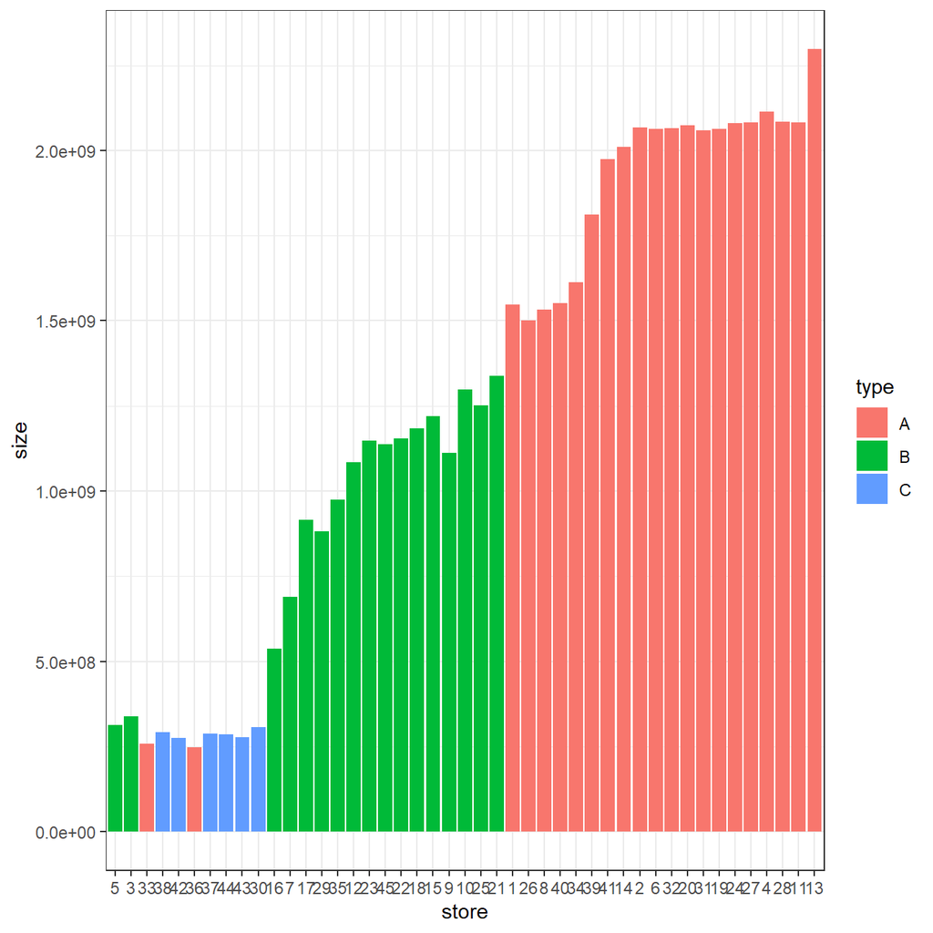

```r
# Graph size per store type
joined_sales %>%
  filter(weekly_sales >= 0) %>%
  mutate(store = fct_reorder(store,size)) %>%
  ggplot(aes(x = store, y = size, fill = type)) +
        geom_col()
```

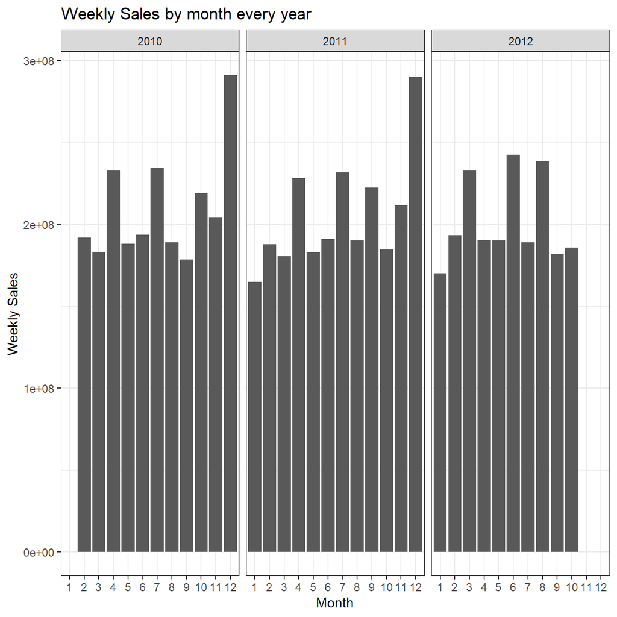

```r
#analysis of how weekly sales varies across months in every year
joined_sales %>%
#extract year from date
  mutate(year = year(date)) %>%
#extract month from date
  mutate(month = as.factor(month(date))) %>%
#create histogram for weekly sales by month
  ggplot(aes(x = month, y = weekly_sales)) +
  geom_col()+
# facet the histogram by year
  facet_wrap(~year) +
  labs(title="Weekly Sales by month every year",x="Month",y="Weekly Sales")
```

When trying to find the store with the most sales in 2011, we isolate store 4, which is indeed categorized as type A. It is also one of the larger stores within type A. Therefore we can already assume that there is a correlation between size of a store and sales, which we will investigate next.

```r
# Calculate store with most sales in 2011
sales %>%
  # Select relevant time frame
  filter(date >= "2011-01-07" & date <= "2011-12-30") %>%
  group_by(store) %>%
  # Calculate summary statistics
  summarize(annl_sales = sum(weekly_sales),
            avg_wkly_sales = mean(weekly_sales)) %>%
            slice_max(annl_sales, n = 2)
```

| store | annl_sales | avg_wkly_sales |
| --- | --- | --- |
| 4 | 1.12e+08 | 3e+04 |
| 20 | 1.11e+08 | 2.97e+04 |

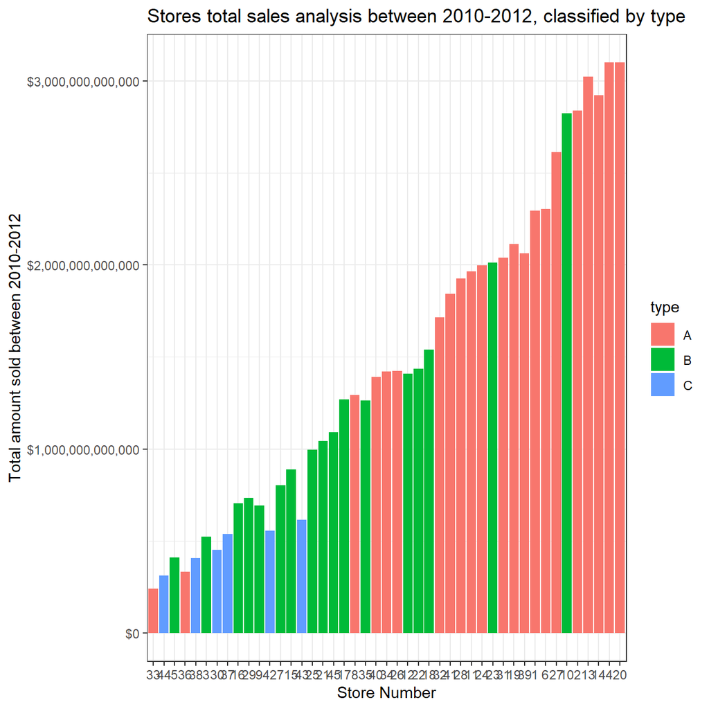

```r
# Create plot to show total sales by store
joined_sales %>%
  group_by(store, type) %>%
  mutate(total_sales_by_store = sum(weekly_sales)) %>%
  ungroup() %>%
  mutate(store_n = fct_reorder(store, total_sales_by_store)) %>%
  ggplot(aes(x=store_n, y = total_sales_by_store, fill=type))+
  geom_col()+
  labs(title ="Stores total sales analysis between 2010-2012, classified by type",
       x = "Store Number",
       y = "Total amount sold between 2010-2012")+
  # Change scale y to show dollar amounts
  scale_y_continuous(labels = scales::label_dollar())
```

Another variable we decided to look at is temperature. If stores have a certain type for other reasons than just size, temperature could hint at this. For example, we would expect stores carrying items typically related to summer to flourish in warmer temperatures. According to the graphs, for type B and C stores sales increases when temperature increases, and on the other hand for type A sales decreases when temperature increases. This could indicate that stores of type B and C sell items that are more tailored to warm temperatures.

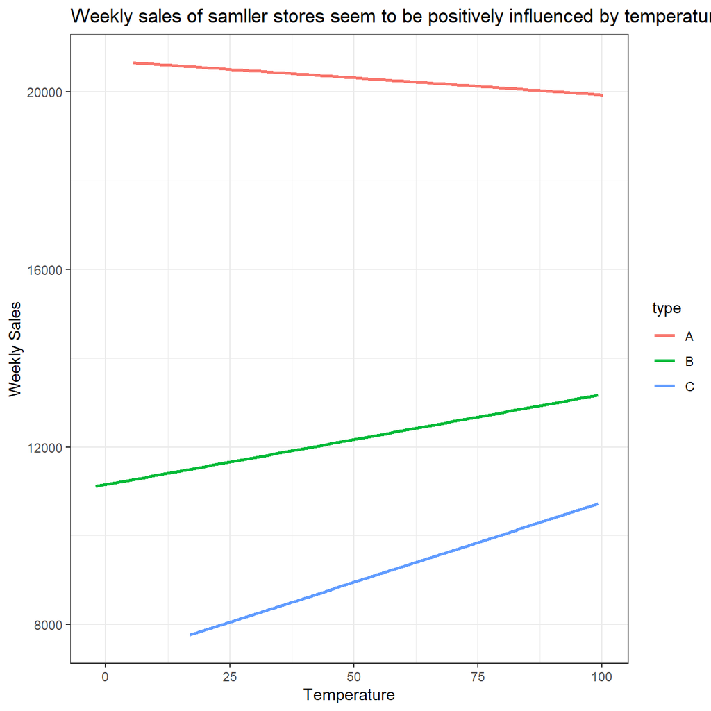

```r
#analysis of how the temperature affects weekly sales by store
joined_sales %>%
  group_by(store) %>%
  #calculate average_weekly_sales_by_store and add it as a new column
  mutate(mean_weekly_sales = mean(weekly_sales)) %>%
  ggplot(aes(x = temperature, y = mean_weekly_sales, color = type)) +
  geom_smooth(method = "lm", se = FALSE) +
  theme_bw()+
  labs(title="Weekly sales of samller stores seem to be positively influenced by temperature",
       x="Temperature",
       y="Weekly Sales")
```

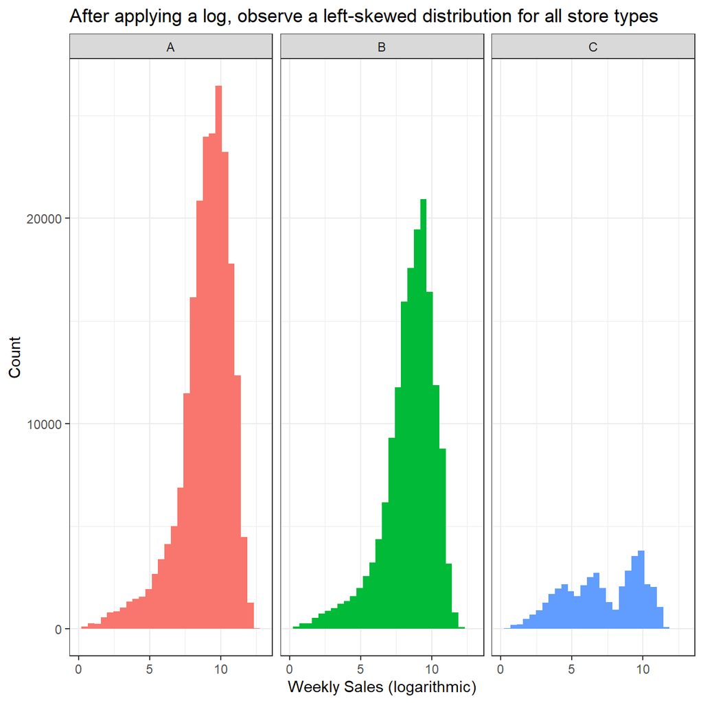

```r
# Create plot for distribution by store type
joined_sales %>%
  # Remove days with negative weekly sales
  filter(weekly_sales >= 0) %>%
  # Add log weekly_sales to account for skewness of graph and outliers
  mutate(log_wkly_sales = log(weekly_sales)) %>%
  ggplot(aes(x = log_wkly_sales, fill = type)) +
  geom_histogram() +
  facet_wrap(~ type) +
  # Set the limits of the x-axis
  xlim(0,13) +
  labs(title = "After applying a log, observe a left-skewed distribution for all store types",
       x = "Weekly Sales (logarithmic)",
       y = "Count") +
  theme(legend.position = "none")
```

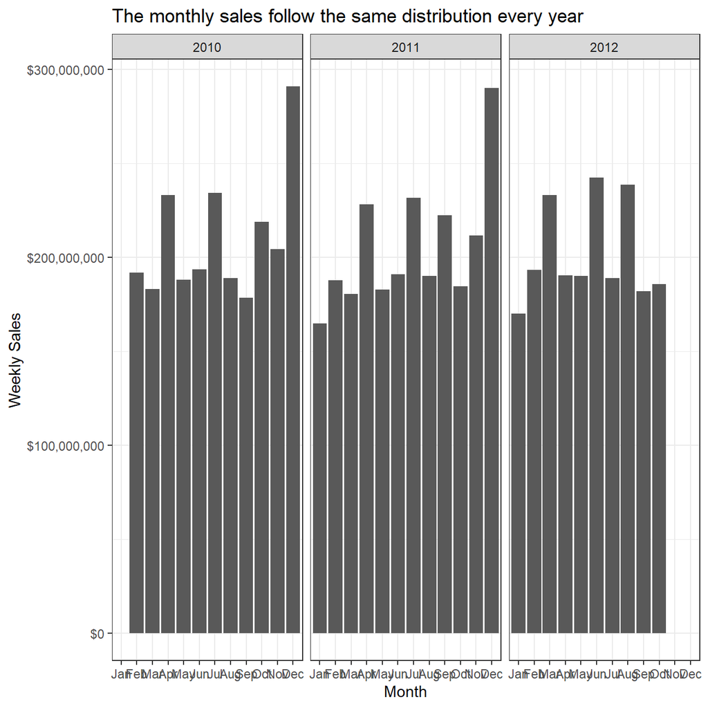

```r
#analysis of how weekly sales varies across months in every year
joined_sales %>%
#extract year from date
  mutate(year = year(date),
         month = as.factor(month(date, label = TRUE))) %>%
#create histogram for weekly sales by month
  ggplot(aes(x = month, y = weekly_sales)) +
  geom_col()+
# facet the histogram by year
  facet_wrap(~year) +
  labs(title="The monthly sales follow the same distribution every year",
       x="Month",
       y="Weekly Sales") +
  scale_y_continuous(labels = scales::label_dollar())
```

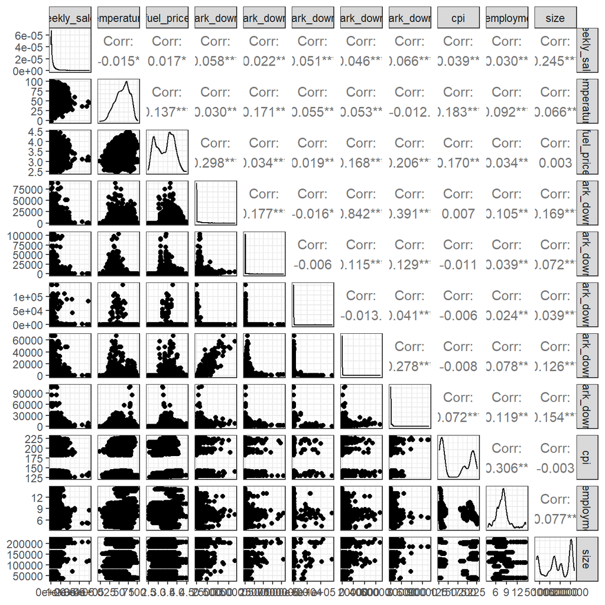

```r
joined_sales %>%
  # Choose random sample from dataframe to make ggpairs run
  sample_n(20000) %>%
  # Select only the numeric values
  select_if(is.numeric) %>%
  GGally::ggpairs()
```

Intuition tells us that a store would expect more sales during holiday weeks, rather than regular trading weeks. When we proceed to calculate the mean and median for holiday and non-holiday weeks and then subtract them from another, we see that only few stores have a lower mean weekly sales in holiday weeks. When we do the same for the median, we also see only few stores, however it concerns different stores than for the mean.

```r
# Calculate mean and median for holiday weeks
mean_med_hol <- joined_sales %>%
  group_by(store) %>%
  filter (is_holiday == TRUE) %>%
  summarize(mean_sales_hol = mean(weekly_sales),
            median_sales_hol = median(weekly_sales))

# Calculate mean and median for normal trading weeks
mean_med_not_hol <- joined_sales %>%
  group_by(store) %>%
  filter (is_holiday == FALSE) %>%
  summarize(mean_sales_not_hol = mean(weekly_sales),
            median_sales_not_hol = median(weekly_sales))

# Joined dataframes above to be able to calculate the difference
joined_mean_med_hol <- mean_med_hol %>%
  left_join(by = "store", y = mean_med_not_hol) %>%
  mutate(difference_mean = mean_sales_hol - mean_sales_not_hol,
         difference_med = median_sales_hol - median_sales_not_hol)

# Arrange the dataframe to see negative values for mean and median
joined_mean_med_hol %>%
  arrange(difference_mean)
```

| store | mean_sales_hol | median_sales_hol | mean_sales_not_hol | median_sales_not_hol | difference_mean | difference_med |
| --- | --- | --- | --- | --- | --- | --- |
| 36 | 8.48e+03 | 2e+03 | 8.66e+03 | 1.9e+03 | -180 | 96.6 |
| 44 | 5.96e+03 | 881 | 6.09e+03 | 797 | -130 | 84.6 |
| 37 | 1.03e+04 | 1.74e+03 | 1.04e+04 | 1.74e+03 | -116 | 5.87 |
| 30 | 8.81e+03 | 1.14e+03 | 8.83e+03 | 1.05e+03 | -25.8 | 86.4 |
| 38 | 7.53e+03 | 879 | 7.54e+03 | 753 | -11.9 | 126 |
| 43 | 1.35e+04 | 1.88e+03 | 1.35e+04 | 1.73e+03 | 45.8 | 145 |
| 33 | 5.85e+03 | 1.05e+03 | 5.76e+03 | 916 | 83.2 | 139 |
| 42 | 1.17e+04 | 1.42e+03 | 1.15e+04 | 1.29e+03 | 199 | 130 |
| 40 | 1.43e+04 | 7.42e+03 | 1.38e+04 | 7.02e+03 | 467 | 397 |
| 25 | 1.08e+04 | 5.56e+03 | 1.03e+04 | 5.59e+03 | 468 | -28.6 |
| 32 | 1.7e+04 | 7.5e+03 | 1.64e+04 | 7.64e+03 | 518 | -133 |
| 3 | 6.96e+03 | 3.09e+03 | 6.38e+03 | 2.8e+03 | 575 | 292 |
| 16 | 8.48e+03 | 4.13e+03 | 7.88e+03 | 4.17e+03 | 608 | -48.8 |
| 5 | 5.65e+03 | 2.85e+03 | 5.04e+03 | 2.59e+03 | 609 | 255 |
| 45 | 1.24e+04 | 6.9e+03 | 1.17e+04 | 6.02e+03 | 677 | 882 |
| 9 | 9.5e+03 | 4.33e+03 | 8.78e+03 | 4.22e+03 | 720 | 109 |
| 22 | 1.61e+04 | 8.73e+03 | 1.52e+04 | 8.31e+03 | 824 | 416 |
| 41 | 1.89e+04 | 9.56e+03 | 1.8e+04 | 8.94e+03 | 882 | 614 |
| 26 | 1.55e+04 | 7.55e+03 | 1.46e+04 | 7.15e+03 | 905 | 400 |
| 8 | 1.41e+04 | 8.13e+03 | 1.32e+04 | 7.16e+03 | 960 | 970 |
| 29 | 9.16e+03 | 4.91e+03 | 8.14e+03 | 4.74e+03 | 1.01e+03 | 169 |
| 23 | 2.09e+04 | 1.28e+04 | 1.98e+04 | 1.2e+04 | 1.08e+03 | 773 |
| 34 | 1.47e+04 | 7.41e+03 | 1.35e+04 | 6.67e+03 | 1.14e+03 | 736 |
| 21 | 1.24e+04 | 7.23e+03 | 1.13e+04 | 6.73e+03 | 1.15e+03 | 495 |
| 15 | 1.01e+04 | 5.16e+03 | 8.99e+03 | 4.8e+03 | 1.16e+03 | 368 |
| 13 | 2.88e+04 | 1.43e+04 | 2.75e+04 | 1.41e+04 | 1.31e+03 | 140 |
| 11 | 2.06e+04 | 1.34e+04 | 1.93e+04 | 1.23e+04 | 1.32e+03 | 1.09e+03 |
| 17 | 1.43e+04 | 6.57e+03 | 1.3e+04 | 6.8e+03 | 1.32e+03 | -227 |
| 18 | 1.71e+04 | 1.02e+04 | 1.58e+04 | 9.35e+03 | 1.33e+03 | 885 |
| 39 | 2.24e+04 | 1.17e+04 | 2.1e+04 | 1.11e+04 | 1.34e+03 | 627 |
| 31 | 2.11e+04 | 9.32e+03 | 1.97e+04 | 8.5e+03 | 1.41e+03 | 822 |
| 1 | 2.32e+04 | 1.14e+04 | 2.18e+04 | 1.03e+04 | 1.45e+03 | 1.15e+03 |
| 7 | 9.78e+03 | 5.33e+03 | 8.31e+03 | 4.54e+03 | 1.47e+03 | 796 |
| 14 | 3.04e+04 | 1.68e+04 | 2.89e+04 | 1.51e+04 | 1.49e+03 | 1.72e+03 |
| 6 | 2.35e+04 | 1.41e+04 | 2.2e+04 | 1.37e+04 | 1.55e+03 | 421 |
| 24 | 2.06e+04 | 1.21e+04 | 1.9e+04 | 1.05e+04 | 1.62e+03 | 1.65e+03 |
| 27 | 2.65e+04 | 1.51e+04 | 2.49e+04 | 1.37e+04 | 1.65e+03 | 1.41e+03 |
| 20 | 3.13e+04 | 1.77e+04 | 2.96e+04 | 1.63e+04 | 1.66e+03 | 1.46e+03 |
| 19 | 2.22e+04 | 1.39e+04 | 2.04e+04 | 1.24e+04 | 1.85e+03 | 1.44e+03 |
| 4 | 3.11e+04 | 1.64e+04 | 2.92e+04 | 1.51e+04 | 1.86e+03 | 1.32e+03 |
| 12 | 1.68e+04 | 9.09e+03 | 1.48e+04 | 8.11e+03 | 1.92e+03 | 982 |
| 2 | 2.9e+04 | 1.62e+04 | 2.69e+04 | 1.43e+04 | 2.09e+03 | 1.87e+03 |
| 28 | 2.08e+04 | 1.3e+04 | 1.87e+04 | 1.09e+04 | 2.1e+03 | 2.12e+03 |
| 35 | 1.62e+04 | 9.94e+03 | 1.37e+04 | 9.17e+03 | 2.43e+03 | 766 |
| 10 | 2.93e+04 | 1.46e+04 | 2.63e+04 | 1.4e+04 | 3.01e+03 | 604 |

```r
joined_mean_med_hol %>%
  arrange(difference_med)
```

| store | mean_sales_hol | median_sales_hol | mean_sales_not_hol | median_sales_not_hol | difference_mean | difference_med |
| --- | --- | --- | --- | --- | --- | --- |
| 17 | 1.43e+04 | 6.57e+03 | 1.3e+04 | 6.8e+03 | 1.32e+03 | -227 |
| 32 | 1.7e+04 | 7.5e+03 | 1.64e+04 | 7.64e+03 | 518 | -133 |
| 16 | 8.48e+03 | 4.13e+03 | 7.88e+03 | 4.17e+03 | 608 | -48.8 |
| 25 | 1.08e+04 | 5.56e+03 | 1.03e+04 | 5.59e+03 | 468 | -28.6 |
| 37 | 1.03e+04 | 1.74e+03 | 1.04e+04 | 1.74e+03 | -116 | 5.87 |
| 44 | 5.96e+03 | 881 | 6.09e+03 | 797 | -130 | 84.6 |
| 30 | 8.81e+03 | 1.14e+03 | 8.83e+03 | 1.05e+03 | -25.8 | 86.4 |
| 36 | 8.48e+03 | 2e+03 | 8.66e+03 | 1.9e+03 | -180 | 96.6 |
| 9 | 9.5e+03 | 4.33e+03 | 8.78e+03 | 4.22e+03 | 720 | 109 |
| 38 | 7.53e+03 | 879 | 7.54e+03 | 753 | -11.9 | 126 |
| 42 | 1.17e+04 | 1.42e+03 | 1.15e+04 | 1.29e+03 | 199 | 130 |
| 33 | 5.85e+03 | 1.05e+03 | 5.76e+03 | 916 | 83.2 | 139 |
| 13 | 2.88e+04 | 1.43e+04 | 2.75e+04 | 1.41e+04 | 1.31e+03 | 140 |
| 43 | 1.35e+04 | 1.88e+03 | 1.35e+04 | 1.73e+03 | 45.8 | 145 |
| 29 | 9.16e+03 | 4.91e+03 | 8.14e+03 | 4.74e+03 | 1.01e+03 | 169 |
| 5 | 5.65e+03 | 2.85e+03 | 5.04e+03 | 2.59e+03 | 609 | 255 |
| 3 | 6.96e+03 | 3.09e+03 | 6.38e+03 | 2.8e+03 | 575 | 292 |
| 15 | 1.01e+04 | 5.16e+03 | 8.99e+03 | 4.8e+03 | 1.16e+03 | 368 |
| 40 | 1.43e+04 | 7.42e+03 | 1.38e+04 | 7.02e+03 | 467 | 397 |
| 26 | 1.55e+04 | 7.55e+03 | 1.46e+04 | 7.15e+03 | 905 | 400 |
| 22 | 1.61e+04 | 8.73e+03 | 1.52e+04 | 8.31e+03 | 824 | 416 |
| 6 | 2.35e+04 | 1.41e+04 | 2.2e+04 | 1.37e+04 | 1.55e+03 | 421 |
| 21 | 1.24e+04 | 7.23e+03 | 1.13e+04 | 6.73e+03 | 1.15e+03 | 495 |
| 10 | 2.93e+04 | 1.46e+04 | 2.63e+04 | 1.4e+04 | 3.01e+03 | 604 |
| 41 | 1.89e+04 | 9.56e+03 | 1.8e+04 | 8.94e+03 | 882 | 614 |
| 39 | 2.24e+04 | 1.17e+04 | 2.1e+04 | 1.11e+04 | 1.34e+03 | 627 |
| 34 | 1.47e+04 | 7.41e+03 | 1.35e+04 | 6.67e+03 | 1.14e+03 | 736 |
| 35 | 1.62e+04 | 9.94e+03 | 1.37e+04 | 9.17e+03 | 2.43e+03 | 766 |
| 23 | 2.09e+04 | 1.28e+04 | 1.98e+04 | 1.2e+04 | 1.08e+03 | 773 |
| 7 | 9.78e+03 | 5.33e+03 | 8.31e+03 | 4.54e+03 | 1.47e+03 | 796 |
| 31 | 2.11e+04 | 9.32e+03 | 1.97e+04 | 8.5e+03 | 1.41e+03 | 822 |
| 45 | 1.24e+04 | 6.9e+03 | 1.17e+04 | 6.02e+03 | 677 | 882 |
| 18 | 1.71e+04 | 1.02e+04 | 1.58e+04 | 9.35e+03 | 1.33e+03 | 885 |
| 8 | 1.41e+04 | 8.13e+03 | 1.32e+04 | 7.16e+03 | 960 | 970 |
| 12 | 1.68e+04 | 9.09e+03 | 1.48e+04 | 8.11e+03 | 1.92e+03 | 982 |
| 11 | 2.06e+04 | 1.34e+04 | 1.93e+04 | 1.23e+04 | 1.32e+03 | 1.09e+03 |
| 1 | 2.32e+04 | 1.14e+04 | 2.18e+04 | 1.03e+04 | 1.45e+03 | 1.15e+03 |
| 4 | 3.11e+04 | 1.64e+04 | 2.92e+04 | 1.51e+04 | 1.86e+03 | 1.32e+03 |
| 27 | 2.65e+04 | 1.51e+04 | 2.49e+04 | 1.37e+04 | 1.65e+03 | 1.41e+03 |
| 19 | 2.22e+04 | 1.39e+04 | 2.04e+04 | 1.24e+04 | 1.85e+03 | 1.44e+03 |
| 20 | 3.13e+04 | 1.77e+04 | 2.96e+04 | 1.63e+04 | 1.66e+03 | 1.46e+03 |
| 24 | 2.06e+04 | 1.21e+04 | 1.9e+04 | 1.05e+04 | 1.62e+03 | 1.65e+03 |
| 14 | 3.04e+04 | 1.68e+04 | 2.89e+04 | 1.51e+04 | 1.49e+03 | 1.72e+03 |
| 2 | 2.9e+04 | 1.62e+04 | 2.69e+04 | 1.43e+04 | 2.09e+03 | 1.87e+03 |
| 28 | 2.08e+04 | 1.3e+04 | 1.87e+04 | 1.09e+04 | 2.1e+03 | 2.12e+03 |

We would also like to take a closer look at the spread of values for each store. We use the logarithmic sales on the axis to better visualize the data, given the high amount of outliers.

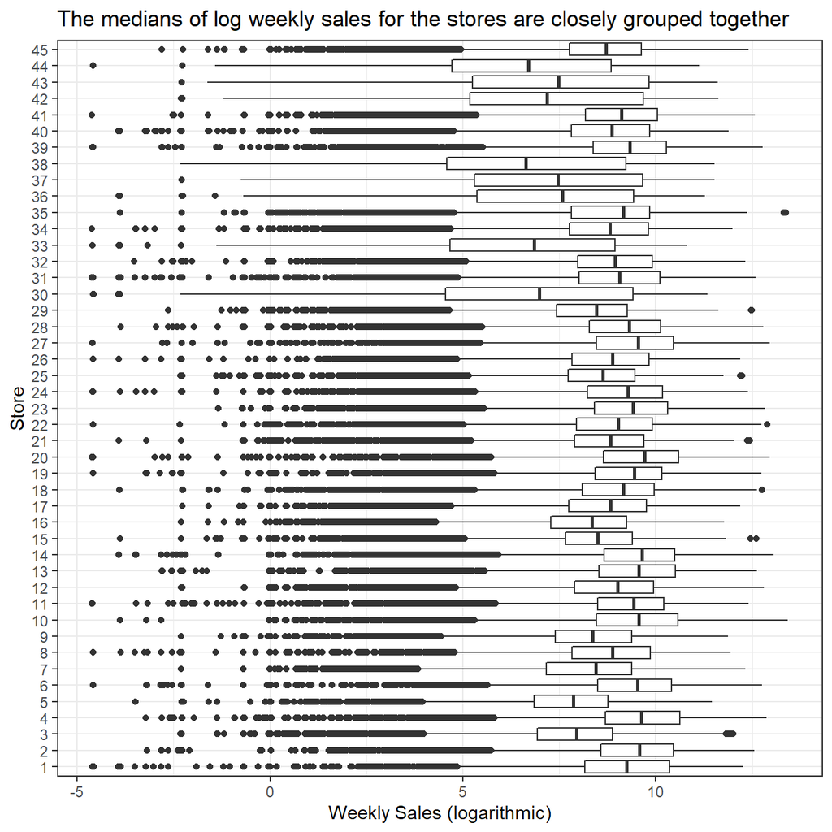

```r
# Create plot for spread per store
joined_sales %>%
  group_by(store) %>%
  mutate(log_wkly_sales = log(weekly_sales)) %>%
  ggplot(aes(x = log_wkly_sales, y = store)) +
  geom_boxplot() +
  labs(title = "The medians of log weekly sales for the stores are closely grouped together",
       x = "Weekly Sales (logarithmic)",
       y = "Store")
```

# 2 Inferential Statistics

```r
#glimpse(joined_sales)
conf_joined_sales <- joined_sales %>%
  #Split the date to get months so that we can identify the holidays
  mutate(year = year(date),
         month = month(date, label = TRUE),
         week = week(date)) %>%
  # Identidy the holidays and call normal day "no holiday"
  mutate(holiday = case_when(
    (is_holiday == TRUE) & (month == "Dec") ~ "Christmas",
    (is_holiday == TRUE) & (month == "Feb") ~ "Super Bowl",
    (is_holiday == TRUE) & (month == "Nov") ~ "Thanksgiving",
    (is_holiday == TRUE) & (month == "Sep") ~ "Labor day",
    (is_holiday == FALSE) ~ "No Holiday"
  ))
```

## 2.1 Differce in impact on sales on different holiday weeks

```r
holiday_sales <- conf_joined_sales %>%
  #Filter the four holidays
filter(is_holiday == TRUE) %>%
  group_by(holiday) %>%
  summarise(mean_weekly_sales = mean(weekly_sales)) %>%
  arrange(desc(mean_weekly_sales))

  holiday_sales
```

| holiday | mean_weekly_sales |
| --- | --- |
| Thanksgiving | 2.24e+04 |
| Super Bowl | 1.65e+04 |
| Labor day | 1.6e+04 |
| Christmas | 1.46e+04 |

Thanksgiving generates the highest weekly sales among holiday weeks which is 22362.

```r
holiday_sales %>%
  filter( holiday %in% c("Thanksgiving", "Labor day")) %>%
   summarise(Name = "Higher thanksgiving sales compared to labor day", diff_sales = abs(diff(mean_weekly_sales)))
```

| Name | diff_sales |
| --- | --- |
| Higher thanksgiving sales compared to labor day | 6.37e+03 |

The difference in average weekly sales between Thanksgiving and Labor day is 6368.

```r
#T-test for data without Thanksgiving
conf_joined_sales %>%
  filter(holiday != "Thanksgiving") %>%
  #Using T-test
  t.test(weekly_sales~is_holiday,.)
```

```
##
##  Welch Two Sample t-test
##
## data:  weekly_sales by is_holiday
## t = 1, df = 26693, p-value = 0.3
## alternative hypothesis: true difference in means between group FALSE and group TRUE is not equal to 0
## 95 percent confidence interval:
##  -124  462
## sample estimates:
## mean in group FALSE  mean in group TRUE
##               16012               15844
```

```r
#T-test for data without Thanksgiving
conf_joined_sales %>%
  filter((holiday == "Thanksgiving") | (holiday == "No Holiday")) %>%
  #Using T-test
  t.test(weekly_sales~is_holiday,.)
```

```
##
##  Welch Two Sample t-test
##
## data:  weekly_sales by is_holiday
## t = -12, df = 6012, p-value <2e-16
## alternative hypothesis: true difference in means between group FALSE and group TRUE is not equal to 0
## 95 percent confidence interval:
##  -7404 -5296
## sample estimates:
## mean in group FALSE  mean in group TRUE
##               16012               22362
```

The difference of sales on holiday weeks and non-holiday weeks is not significant when filtering out Thanksgiving from the data since the P value from the T-test is greater than 5%. However, when we look at the average weekly_sales in the week of thanksgiving, we can observe that 0 is not within the 95% confidence interval. We conclude with a 95% confidence that there truly is a difference in means between weekly sales in the Thanksgiving week vs non-holiday weeks.

From the results of the t-test, when analyzing on the basis of weeks, we can see that the sales are highest in the week of Thanksgiving. The sales in the weeks of other occasions is not that differential. This could be following the trend that during holidays such as Christmas people tend to fly back home and buy gifts earlier. Hence, the sales could be higher when looking at monthly sales.

# 3 Regression

We calculate the weekly sales by store, so that we won’t have 1:n format for variables like temperature. We remove the variable store because it’s not an explanatory variable. And for Markdown have too many missing variables, we don’t include it in the model

```r
sales_by_store <- joined_sales %>%
  mutate(type = as.factor(type)) %>%
  group_by(store,date) %>%
  summarize(weekly_sales = sum(weekly_sales)) %>%
  left_join(by = c("store","date"), y = details) %>%
  left_join(by = "store", y = stores) %>%
  mutate(type = as.factor(type)) %>%
  mutate(month = as.factor(month(date))) %>%
  # Identify the holidays and call normal day no holiday"
  mutate(holiday = case_when(
    (is_holiday == TRUE) & (month == 2) ~ "Super Bowl",
    (is_holiday == TRUE) & (month == 9) ~ "Labor Day",
    (is_holiday == TRUE) & (month == 11) ~ "Thanksgiving",
    (is_holiday == TRUE) & (month == 12) ~ "Christmas",
    (is_holiday == FALSE) ~ "No Holiday")) %>%
  mutate(holiday = as.factor(holiday))

model0 <- lm(weekly_sales~.-store-month-is_holiday,data=sales_by_store)
msummary(model0)
```

```
##                      Estimate Std. Error t value Pr(>|t|)
## (Intercept)          1.44e+06   3.90e+05    3.68  0.00023 ***
## date                -7.66e+01   2.79e+01   -2.74  0.00617 **
## temperature          1.59e+03   2.43e+02    6.55  6.2e-11 ***
## fuel_price          -1.36e+04   1.54e+04   -0.88  0.37912
## mark_down1           2.25e+00   1.43e+00    1.57  0.11544
## mark_down2           2.44e+00   9.54e-01    2.56  0.01053 *
## mark_down3           5.87e+00   9.42e-01    6.23  5.0e-10 ***
## mark_down4           4.02e-01   2.01e+00    0.20  0.84122
## mark_down5           6.05e+00   1.15e+00    5.28  1.3e-07 ***
## cpi                 -1.40e+03   1.15e+02  -12.13  < 2e-16 ***
## unemployment        -2.60e+04   2.43e+03  -10.69  < 2e-16 ***
## typeB                4.49e+04   1.18e+04    3.80  0.00015 ***
## typeC                1.97e+05   1.90e+04   10.37  < 2e-16 ***
## size                 7.83e+00   1.05e-01   74.50  < 2e-16 ***
## holidayLabor Day     7.43e+04   4.78e+04    1.55  0.12023
## holidayNo Holiday    8.46e+04   3.87e+04    2.18  0.02893 *
## holidaySuper Bowl    1.46e+05   4.70e+04    3.11  0.00186 **
## holidayThanksgiving  3.90e+05   5.68e+04    6.87  7.2e-12 ***
##
## Residual standard error: 319000 on 6417 degrees of freedom
## Multiple R-squared:  0.685,  Adjusted R-squared:  0.684
## F-statistic:  822 on 17 and 6417 DF,  p-value: <2e-16
```

```r
vif(model0)
```

```
##              GVIF Df GVIF^(1/(2*Df))
## date         4.12  1            2.03
## temperature  1.27  1            1.13
## fuel_price   3.17  1            1.78
## mark_down1   4.45  1            2.11
## mark_down2   1.37  1            1.17
## mark_down3   1.56  1            1.25
## mark_down4   3.58  1            1.89
## mark_down5   1.39  1            1.18
## cpi          1.30  1            1.14
## unemployment 1.31  1            1.14
## type         2.88  2            1.30
## size         2.78  1            1.67
## holiday      2.20  4            1.10
```

Look at the correlations between each variable, and add each variable one by one according to the correlation

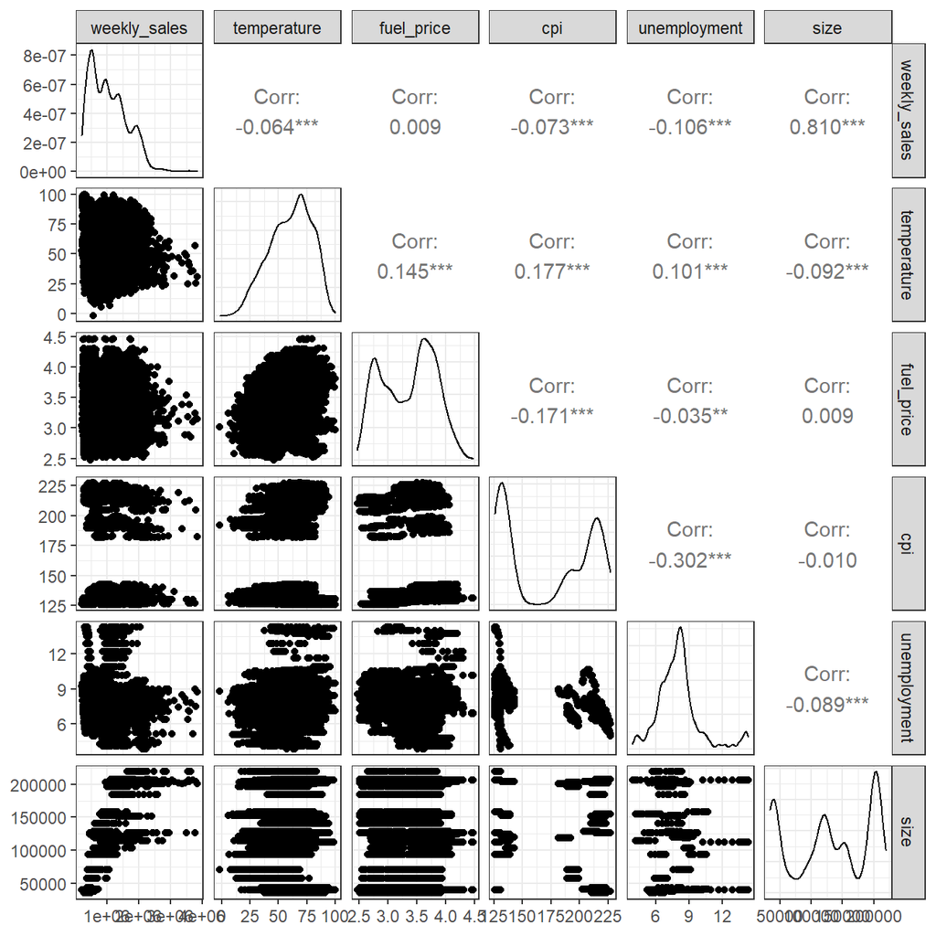

```r
ggpairs(sales_by_store[,c("weekly_sales","temperature","fuel_price","cpi","unemployment","size")])
```

First, we simply add size as a predictor, it’s significant and explains huge amount of variability of the model.

```r
# Create regression for size
model1 <- lm(weekly_sales~size,
             data=sales_by_store)
msummary(model1)
```

```
##             Estimate Std. Error t value Pr(>|t|)
## (Intercept) 1.03e+05   9.52e+03    10.9   <2e-16 ***
## size        7.30e+00   6.58e-02   111.0   <2e-16 ***
##
## Residual standard error: 333000 on 6433 degrees of freedom
## Multiple R-squared:  0.657,  Adjusted R-squared:  0.657
## F-statistic: 1.23e+04 on 1 and 6433 DF,  p-value: <2e-16
```

Next, we add back the observed holidays as a predictor.

```r
# Adding holidays back into the model
model2 <- lm(weekly_sales~size+holiday,
             data=sales_by_store)
msummary(model2)
```

```
##                     Estimate Std. Error t value Pr(>|t|)
## (Intercept)         1.67e+04   3.57e+04    0.47   0.6406
## size                7.30e+00   6.50e-02  112.30   <2e-16 ***
## holidayLabor Day    8.24e+04   4.48e+04    1.84   0.0659 .
## holidayNo Holiday   8.10e+04   3.49e+04    2.32   0.0204 *
## holidaySuper Bowl   1.19e+05   4.48e+04    2.67   0.0077 **
## holidayThanksgiving 5.13e+05   4.90e+04   10.46   <2e-16 ***
##
## Residual standard error: 329000 on 6429 degrees of freedom
## Multiple R-squared:  0.665,  Adjusted R-squared:  0.665
## F-statistic: 2.55e+03 on 5 and 6429 DF,  p-value: <2e-16
```

Next, we include the unemployment rate, which we would expect to affect consumer spending.

```r
# Add unemployment rate to the model
model3 <- lm(weekly_sales~size+holiday+unemployment,
             data=sales_by_store)
msummary(model3)
```

```
##                      Estimate Std. Error t value Pr(>|t|)
## (Intercept)          1.07e+05   4.02e+04    2.66   0.0079 **
## size                 7.27e+00   6.51e-02  111.62  < 2e-16 ***
## holidayLabor Day     8.00e+04   4.47e+04    1.79   0.0734 .
## holidayNo Holiday    7.95e+04   3.49e+04    2.28   0.0227 *
## holidaySuper Bowl    1.19e+05   4.47e+04    2.67   0.0076 **
## holidayThanksgiving  5.13e+05   4.90e+04   10.48  < 2e-16 ***
## unemployment        -1.06e+04   2.19e+03   -4.85  1.3e-06 ***
##
## Residual standard error: 328000 on 6428 degrees of freedom
## Multiple R-squared:  0.666,  Adjusted R-squared:  0.666
## F-statistic: 2.14e+03 on 6 and 6428 DF,  p-value: <2e-16
```

As we have seen earlier, temperature seemed to have some effect on the sales of the stores. Let us see whether it is signficant in predicting sales.

```r
# Add temperature to the model
model4 <- lm(weekly_sales~size+holiday+unemployment+temperature,
             data=sales_by_store)
msummary(model4)
```

```
##                      Estimate Std. Error t value Pr(>|t|)
## (Intercept)          8.35e+04   4.09e+04    2.04   0.0411 *
## size                 7.29e+00   6.53e-02  111.53  < 2e-16 ***
## holidayLabor Day     5.33e+04   4.55e+04    1.17   0.2420
## holidayNo Holiday    6.22e+04   3.53e+04    1.76   0.0784 .
## holidaySuper Bowl    1.21e+05   4.47e+04    2.70   0.0069 **
## holidayThanksgiving  5.05e+05   4.90e+04   10.31  < 2e-16 ***
## unemployment        -1.13e+04   2.20e+03   -5.14  2.8e-07 ***
## temperature          7.14e+02   2.34e+02    3.05   0.0023 **
##
## Residual standard error: 328000 on 6427 degrees of freedom
## Multiple R-squared:  0.667,  Adjusted R-squared:  0.667
## F-statistic: 1.84e+03 on 7 and 6427 DF,  p-value: <2e-16
```

Fuel price could also be a significant predictor, given that higher prices might cause consumers not to travel to further away stores, negatively affecting their sales.

```r
# Add fuel price to the plot
model5 <- lm(weekly_sales~size+holiday+unemployment+temperature+fuel_price,
             data=sales_by_store)
msummary(model5)
```

```
##                      Estimate Std. Error t value Pr(>|t|)
## (Intercept)          7.43e+04   4.96e+04    1.50   0.1345
## size                 7.29e+00   6.54e-02  111.50  < 2e-16 ***
## holidayLabor Day     5.29e+04   4.55e+04    1.16   0.2456
## holidayNo Holiday    6.18e+04   3.53e+04    1.75   0.0804 .
## holidaySuper Bowl    1.21e+05   4.47e+04    2.71   0.0068 **
## holidayThanksgiving  5.05e+05   4.90e+04   10.31  < 2e-16 ***
## unemployment        -1.13e+04   2.20e+03   -5.12  3.2e-07 ***
## temperature          7.04e+02   2.36e+02    2.99   0.0028 **
## fuel_price           2.97e+03   9.04e+03    0.33   0.7424
##
## Residual standard error: 328000 on 6426 degrees of freedom
## Multiple R-squared:  0.667,  Adjusted R-squared:  0.666
## F-statistic: 1.61e+03 on 8 and 6426 DF,  p-value: <2e-16
```

While fuel price is at first not significant, after we add type and cpi, fuel price indeed significant.

```r
# Add type and cpi into the model
model6 <- lm(weekly_sales~size+holiday+unemployment+cpi+temperature+type+fuel_price,
             data=sales_by_store)
msummary(model6)
```

```
##                      Estimate Std. Error t value Pr(>|t|)
## (Intercept)          3.57e+05   5.92e+04    6.02  1.8e-09 ***
## size                 7.99e+00   1.04e-01   76.69  < 2e-16 ***
## holidayLabor Day     3.34e+04   4.47e+04    0.75   0.4552
## holidayNo Holiday    5.00e+04   3.46e+04    1.44   0.1487
## holidaySuper Bowl    1.20e+05   4.38e+04    2.75   0.0061 **
## holidayThanksgiving  4.98e+05   4.80e+04   10.36  < 2e-16 ***
## unemployment        -2.55e+04   2.34e+03  -10.92  < 2e-16 ***
## cpi                 -1.40e+03   1.13e+02  -12.36  < 2e-16 ***
## temperature          1.37e+03   2.42e+02    5.65  1.7e-08 ***
## typeB                4.92e+04   1.19e+04    4.14  3.5e-05 ***
## typeC                1.96e+05   1.91e+04   10.28  < 2e-16 ***
## fuel_price          -2.49e+04   9.11e+03   -2.73   0.0063 **
##
## Residual standard error: 322000 on 6423 degrees of freedom
## Multiple R-squared:  0.68,   Adjusted R-squared:  0.68
## F-statistic: 1.24e+03 on 11 and 6423 DF,  p-value: <2e-16
```

Finally, we summarize of all the models to make them comparable to one another.

```r
# Create summary table for all models - note that we have model0, so there will be model 7 in the table
huxreg(model0, model1,  model2, model3, model4, model5, model6,
       statistics = c('#observations' = 'nobs',
                      'R squared' = 'r.squared',
                      'Adj. R Squared' = 'adj.r.squared',
                      'Residual SE' = 'sigma'),
       bold_signif = 0.05,
       stars = NULL
)
```

|  | (1) | (2) | (3) | (4) | (5) | (6) | (7) |
| --- | --- | --- | --- | --- | --- | --- | --- |
| (Intercept) | 1437616.961 | 103438.206 | 16668.585 | 106824.661 | 83525.289 | 74280.095 | 356706.733 |
|  | (390206.121) | (9521.614) | (35698.590) | (40197.124) | (40889.604) | (49631.766) | (59234.982) |
| date | -76.554 |  |  |  |  |  |  |
|  | (27.946) |  |  |  |  |  |  |
| temperature | 1591.364 |  |  |  | 713.739 | 703.888 | 1367.028 |
|  | (242.946) |  |  |  | (233.779) | (235.709) | (241.922) |
| fuel_price | -13589.330 |  |  |  |  | 2972.807 | -24909.888 |
|  | (15449.720) |  |  |  |  | (9044.236) | (9114.618) |
| mark_down1 | 2.251 |  |  |  |  |  |  |
|  | (1.430) |  |  |  |  |  |  |
| mark_down2 | 2.441 |  |  |  |  |  |  |
|  | (0.954) |  |  |  |  |  |  |
| mark_down3 | 5.867 |  |  |  |  |  |  |
|  | (0.942) |  |  |  |  |  |  |
| mark_down4 | 0.402 |  |  |  |  |  |  |
|  | (2.007) |  |  |  |  |  |  |
| mark_down5 | 6.050 |  |  |  |  |  |  |
|  | (1.146) |  |  |  |  |  |  |
| cpi | -1399.551 |  |  |  |  |  | -1395.683 |
|  | (115.417) |  |  |  |  |  | (112.956) |
| unemployment | -25967.820 |  |  | -10625.293 | -11317.702 | -11284.660 | -25521.213 |
|  | (2429.003) |  |  | (2191.788) | (2202.081) | (2204.527) | (2336.601) |
| typeB | 44921.747 |  |  |  |  |  | 49184.685 |
|  | (11836.087) |  |  |  |  |  | (11884.575) |
| typeC | 196646.438 |  |  |  |  |  | 196257.197 |
|  | (18961.241) |  |  |  |  |  | (19082.841) |
| size | 7.835 | 7.298 | 7.298 | 7.270 | 7.287 | 7.287 | 7.986 |
|  | (0.105) | (0.066) | (0.065) | (0.065) | (0.065) | (0.065) | (0.104) |
| holidayLabor Day | 74315.743 |  | 82352.858 | 80029.933 | 53262.593 | 52877.198 | 33358.181 |
|  | (47821.959) |  | (44771.708) | (44696.134) | (45519.547) | (45537.803) | (44668.349) |
| holidayNo Holiday | 84621.405 |  | 81027.379 | 79473.518 | 62175.659 | 61797.055 | 50041.115 |
|  | (38729.653) |  | (34939.795) | (34880.285) | (35315.185) | (35336.414) | (34645.796) |
| holidaySuper Bowl | 146369.597 |  | 119360.966 | 119359.471 | 120764.223 | 120865.446 | 120156.117 |
|  | (47025.204) |  | (44771.708) | (44693.565) | (44667.035) | (44671.196) | (43763.315) |
| holidayThanksgiving | 389884.746 |  | 513136.470 | 513136.470 | 504996.910 | 505060.237 | 497564.557 |
|  | (56782.971) |  | (49044.949) | (48959.347) | (49000.271) | (49004.050) | (48014.981) |
| #observations | 6435 | 6435 | 6435 | 6435 | 6435 | 6435 | 6435 |
| R squared | 0.685 | 0.657 | 0.665 | 0.666 | 0.667 | 0.667 | 0.680 |
| Adj. R Squared | 0.684 | 0.657 | 0.665 | 0.666 | 0.667 | 0.666 | 0.680 |
| Residual SE | 319275.320 | 332983.500 | 329003.521 | 328429.287 | 328216.915 | 328239.693 | 321568.254 |

Based on our model, we offer two answers to the questions posed in the instructions:

1. A unit increase in temperature will cause a 1370 increase in sales. A unit increase in fuel_price will cause a 24900 decrease in sales.
2. On average, we expect to generate 86600 revenues less in the Labor Day week than in the week of the Super Bowl

```r
msummary(model6)
```

```
##                      Estimate Std. Error t value Pr(>|t|)
## (Intercept)          3.57e+05   5.92e+04    6.02  1.8e-09 ***
## size                 7.99e+00   1.04e-01   76.69  < 2e-16 ***
## holidayLabor Day     3.34e+04   4.47e+04    0.75   0.4552
## holidayNo Holiday    5.00e+04   3.46e+04    1.44   0.1487
## holidaySuper Bowl    1.20e+05   4.38e+04    2.75   0.0061 **
## holidayThanksgiving  4.98e+05   4.80e+04   10.36  < 2e-16 ***
## unemployment        -2.55e+04   2.34e+03  -10.92  < 2e-16 ***
## cpi                 -1.40e+03   1.13e+02  -12.36  < 2e-16 ***
## temperature          1.37e+03   2.42e+02    5.65  1.7e-08 ***
## typeB                4.92e+04   1.19e+04    4.14  3.5e-05 ***
## typeC                1.96e+05   1.91e+04   10.28  < 2e-16 ***
## fuel_price          -2.49e+04   9.11e+03   -2.73   0.0063 **
##
## Residual standard error: 322000 on 6423 degrees of freedom
## Multiple R-squared:  0.68,   Adjusted R-squared:  0.68
## F-statistic: 1.24e+03 on 11 and 6423 DF,  p-value: <2e-16
```